# Chicago Blackhawks: Scoring Density Analysis for the 2018-2019 Season

Matt Kmiecik

These are the packages used for this analysis:

```r
pkgs <- c("httr", "jsonlite", "tidyverse", "RColorBrewer")
xfun::pkg_attach(pkgs)

# Plotting essentials
rdgy_pal <- brewer.pal(11, "RdGy") # display.brewer.pal(11, "RdGy")
```

The data for this analysis were retrived via the nhl.com API. I developed a function to bypass some of the extraction formating. The function is called `nhl_api()`.

```r
# Function to retrive api data and clean
# input is a call link to the nhl.com API
nhl_api <- function(link){

  GET(url = link) %>% content(as = "text") %>% fromJSON()

}
```

If you are unfamiliar with the calls to the nhl.com API, I highly recommend visiting this gitlab site: https://gitlab.com/dword4/nhlapi/blob/master/stats-api.md#game-ids

I retrived all the live data for the Chicago Blackhawks 2018 - 2019 regular season. Then, I filtered these data down to just the goals scored. But before I could do that, I needed to retrieve the game IDs from the schedule. The code below details this process using the `purrr` package (i.e., `map()` functions).

```r
# Blackhawks 2018-2019 schedule (doing this to get game ID)
schedule_link <- "https://statsapi.web.nhl.com/api/v1/schedule?teamId=16&startDate=2018-10-01&endDate=2019-07-01"
schedule_data <- nhl_api(schedule_link) # retrieves schedule data
games_data <- schedule_data$dates$games # grabs games data
games_data_flat <- map_dfr(games_data, jsonlite::flatten) # flattens nested dfs
hawks_games <- games_data_flat$gamePk # THESE ARE THE HAWKS GAME IDs FOR 2018-2019

# Live Feed #

# Assembles links for api cals
game_links <- hawks_games %>%
  map(function(x) paste0("https://statsapi.web.nhl.com/api/v1/game/", x,"/feed/live"))

# Using these above links, the api makes the calls for all 82 games
game_list <- game_links %>% map(~ nhl_api(.x))

# Extracts play data
all_live_data <- game_list %>%
  map("liveData") %>%
  map("plays") %>%
  map("allPlays") %>%
  map_dfr(~ .x %>% select(-players) %>% jsonlite::flatten(), .id = "game_number")

# Filter to only goals
all_goals <- all_live_data %>%
  filter(result.event == "Goal") %>%
  as_tibble() %>%
  mutate(
    about.periodTime = as.numeric(gsub(":", ".", about.periodTime)),
    Team = ifelse(team.name == "Chicago Blackhawks", "Blackhawks", "NHL"),
    GWG = ifelse(result.gameWinningGoal == TRUE, "Game Winning Goal", "Non-Game Winning Goal")
    )

# Filtering to only look at regulation goals
all_reg_goals <- all_goals %>% filter(about.period %in% c(1:3))
```

We’ve all heard Wayne Gretzky’s famous quote, “You miss 100% of the shots you don’t take.” Historically, the [Chicago Blackhawks](https://blackhawkup.com/) have taken Gretzky’s advice to heart and are one of the top four most efficient offenses since 2007 (for a statistical analysis see my previous [article](https://blackhawkup.com/2019/06/27/chicago-blackhawks-efficient-offensive-machine/)). So what went wrong last year? Whispers among internet hockey pundits and enthusiasts will point towards several explanations: age of the core players, the team losing their edge, the coach transition…however, if you listen closely, the whispers start to form a palatable din: the defense.

Anecdotally, the majority of the games I watched seemed to follow a similar theme–the Hawks’ would grab an early lead only to struggle to keep it in the third period, subsequently falling in overtime. Let’s not rely on my memory though, but examine and visualize the **timing of** goals scored for and against the Blackhawks for their entire 82 game 2018-2019 campaign. The Blackhawks shot the puck 2,669 times last season, so let’s examine the 10% that lit the lamp, as well as the 10.2% that made it past the Blackhawks’ net-minders.

The analysis that follows was performed on data retrieved from the [NHL.com](https://www.nhl.com/) API and all `R` code is available on my [Github account](https://github.com/mkmiecik14/Blackhawk-Up).

First, I plotted the scoring density for the Chicago Blackhawks and their opponents across the 82 game regular season.

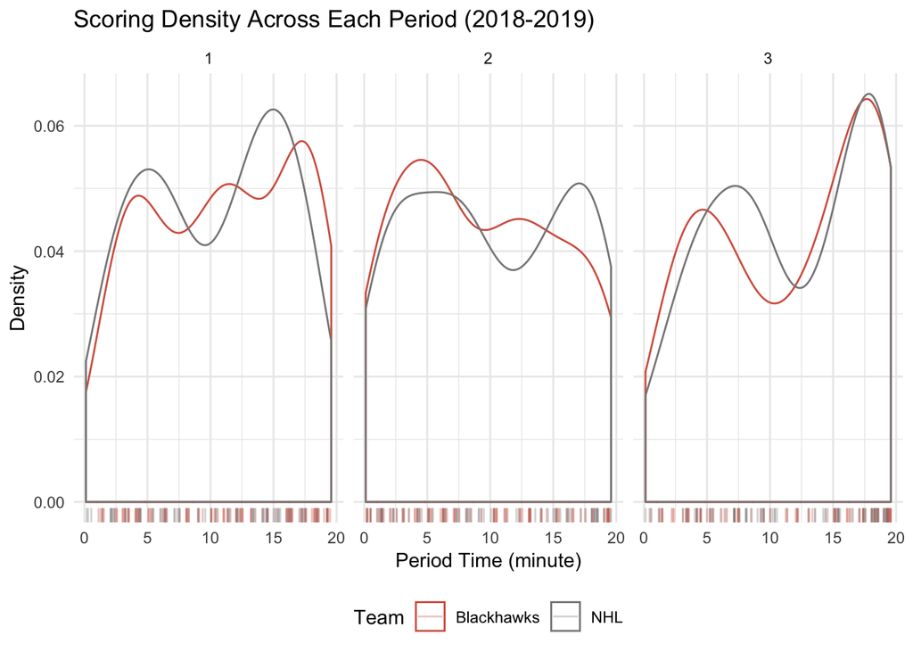

```r
# Total Scoring Density
ggplot(
  all_reg_goals,
  aes(about.periodTime, group = Team, color = Team)
  ) +
  geom_density() +
  geom_rug(alpha = 1/3) +
  scale_color_manual(values = c(rdgy_pal[3], rdgy_pal[9])) +
  labs(
    x = "Period Time (minute)",
    y = "Density",
    title = "Scoring Density Across Each Period (2018-2019)"
    ) +
  facet_wrap(~about.period) +
  theme_minimal() +
  theme(legend.position = "bottom")
```

Another interesting question is when were other NHL teams scoring game winning goals that the Hawks’ just couldn’t overcome? The plot below depicts the scoring density of game winning goals (top panel) and non-game winning goals (bottom panel).

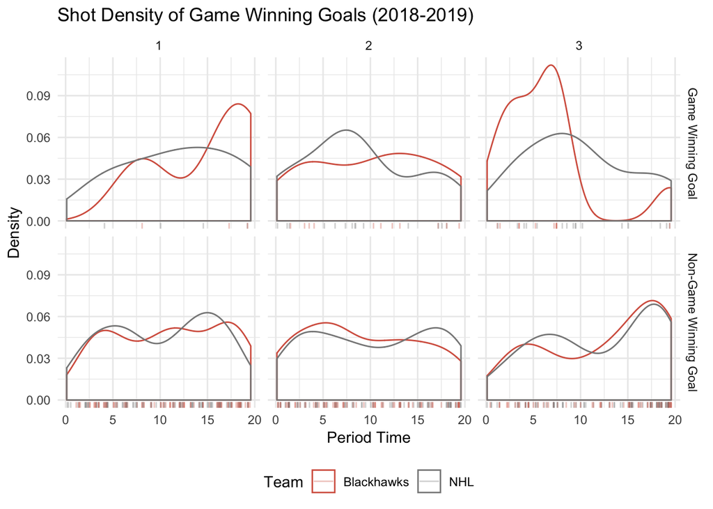

```r
# Game-winning goals
ggplot(
  all_reg_goals,
  aes(about.periodTime, group = Team, color = Team)
  ) +
  geom_density() +
  geom_rug(alpha = 1/3) +
  scale_color_manual(values = c(rdgy_pal[3], rdgy_pal[9])) +
  labs(
    x = "Period Time",
    y = "Density",
    title = "Shot Density of Game Winning Goals (2018-2019)"
    ) +
  facet_grid(GWG~about.period) +
  theme_minimal() +
  theme(legend.position = "bottom")
```

A striking pattern that emerges is the game winning goals scored in the third period. The Blackhawks were excellent at putting games away early in the thrid; however, this pattern completly reverses past the 10 minute mark. This provides precise time evidence of when the Blackhawks’ were losing games (see also the 2nd period).

Now what about the trend I mentioned earlier? Hawks get an early lead, lose the lead in the third period, and then come up short in OT. Let’s examine goals that tie the game:

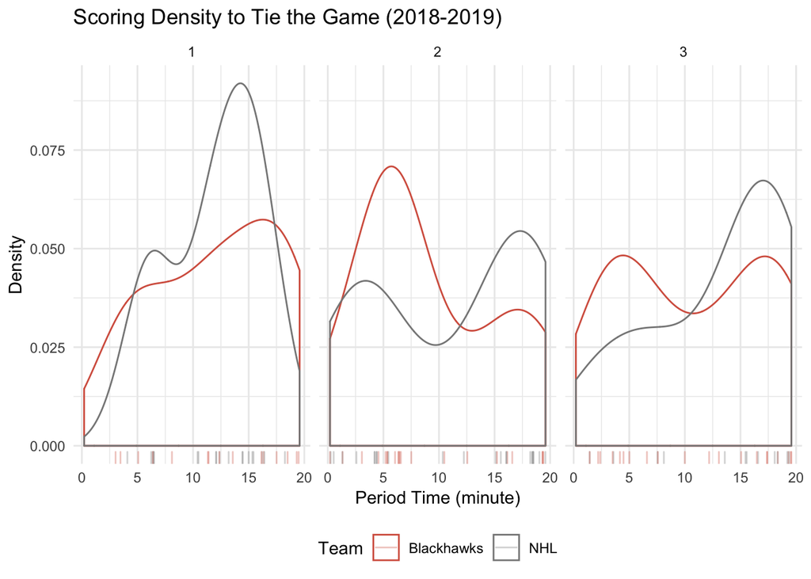

```r
# Goals that tie the game
ggplot(
  all_reg_goals %>% filter(about.goals.away == about.goals.home),
  aes(about.periodTime, group = Team, color = Team)
  ) +
  geom_density() +
  geom_rug(alpha = 1/3) +
  scale_color_manual(values = c(rdgy_pal[3], rdgy_pal[9])) +
  labs(
    x = "Period Time (minute)",
    y = "Density",
    title = "Scoring Density to Tie the Game (2018-2019)"
    ) +
  facet_wrap(~about.period) +
  theme_minimal() +
  theme(legend.position = "bottom")
```

Again, a dichotomous relationship appears in the third period. The Hawks’ were good at tieing games at the beginning of the 2nd and 3rd periods; however, their opponents tended to tie games late in the third.

If you are curious about the OT scoring density, a similar story emerges:

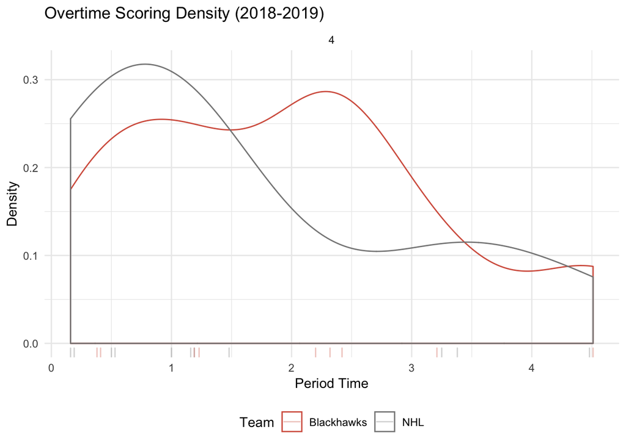

```r
# OT
all_ot_goals <- all_goals %>% filter(about.period == 4)

ggplot(
  all_ot_goals,
  aes(about.periodTime, group = Team, color = Team)
  ) +
  geom_density() +
  geom_rug(alpha = 1/3) +
  scale_color_manual(values = c(rdgy_pal[3], rdgy_pal[9])) +
  labs(
    x = "Period Time",
    y = "Density",
    title = "Overtime Scoring Density (2018-2019)"
    ) +
  facet_wrap(~about.period) +
  theme_minimal() +
  theme(legend.position = "bottom")
```

```r
all_ot_goals %>% count(Team) # Counts of OT goals
```

```
## # A tibble: 2 x 2
##   Team           n
##   <chr>      <int>
## 1 Blackhawks     9
## 2 NHL           11
```

If you were watching the OTs last season, you probably remember the rise in excitement when the puck was dropped, only for it to be ripped from your heart just seconds later. Their opponents tended to put OT games away early, but the Hawks’ tended to win if they could survive the first few minutes. The Hawks ultimately won 9 OT games while losing in 11.

What kinds of shots were the Blackhawks’ defensemen and goalies most susceptible to?

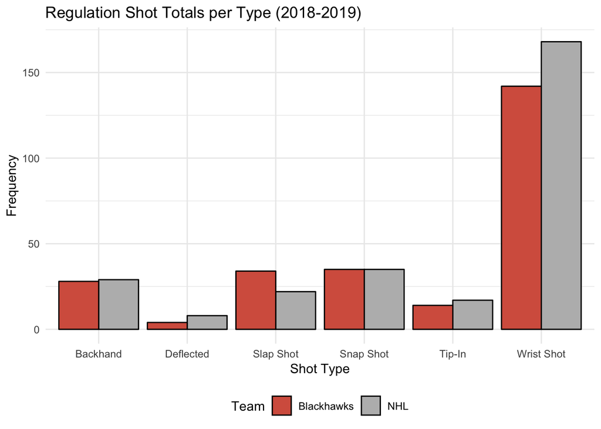

```r
# Types of shots
shot_type_counts <- all_reg_goals %>% group_by(Team) %>% count(result.secondaryType)

ggplot(shot_type_counts %>% filter(n>1), aes(result.secondaryType, n, group = Team, fill = Team)) +
  geom_bar(stat = "identity", position = "dodge", color = "black") +
  scale_fill_manual(values = c(rdgy_pal[3], rdgy_pal[8])) +
  labs(
    x = "Shot Type",
    y = "Frequency",
    title = "Regulation Shot Totals per Type (2018-2019)"
    ) +
  theme_minimal() +
  theme(legend.position = "bottom")
```

```r
all_reg_goals %>% count(Team)
```

```
## # A tibble: 2 x 2
##   Team           n
##   <chr>      <int>
## 1 Blackhawks   258
## 2 NHL          280
```

Across all regulation minutes, the Blackhawks had a tough time defending the wrist shot more so than other shot types.

Overall, the shot density data across the 2018-2019 support most of my anecdoatal experience with watching the Blackhawks’ last season. This largely explains all the defensive moves Stan Bowman has been making in this rollercoaster of an offseason. Hopefully the Hawks’ can improve their defensive slump next season by holding leads, defending against the wrist shot (less open space on the ice), and improving their OT performance, especially in the first few crucial minutes.